# machineLearningAssignment

Yasneen Ashroff

June 22, 2016

# Synopsis

Using devices such as Jawbone Up, Nike FuelBand, and Fitbit it is now possible to collect a large amount of data about personal activity relatively inexpensively. These type of devices are part of the quantified self movement - a group of enthusiasts who take measurements about themselves regularly to improve their health, to find patterns in their behavior, or because they are tech geeks. One thing that people regularly do is quantify how much of a particular activity they do, but they rarely quantify how well they do it. In this project, your goal will be to use data from accelerometers on the belt, forearm, arm, and dumbell of 6 participants. They were asked to perform barbell lifts correctly and incorrectly in 5 different ways. More information is available from the website here: http://groupware.les.inf.puc-rio.br/har (see the section on the Weight Lifting Exercise Dataset).

# Data Processing

The training data for this project are available here:

https://d396qusza40orc.cloudfront.net/predmachlearn/pml-training.csv

The test data are available here:

https://d396qusza40orc.cloudfront.net/predmachlearn/pml-testing.csv

```r
require(caret)
require(RGtk2)
require(rattle)
require(cacher)
```

```r
require(rpart.plot)
```

# Data Loading and Cleaning

read in the data. Anything with NA or DIV/0 should be considered a null value.

```r
training=read.csv('pml-training.csv',na.strings=c("NA", "", "#DIV/0!"))
testing=read.csv('pml-testing.csv',na.strings=c("NA", "", "#DIV/0!"))
```

clean the data: Data appears to be a time series with the presence of windows and timestamps, but it does not seem that the data within a time period is dependent on other observations in the same time period. Hence we will remove the time period data from the analysis.; Remove first 7 columns:

```r
training<-subset(training[,8:160])
testing<-subset(testing[,8:160])
```

Some columns are only populated once per window. Remove any columns with more than 95% NA values

```r
training<-training[,colSums(is.na(training))<(0.95*nrow(training))]
testing<-testing[,colSums(is.na(testing))<(0.95*nrow(testing))]
```

# Exploratory Data Analysis

Create feature plots of totals from each category (belt, arm, dumbbell, forearm) vs classe

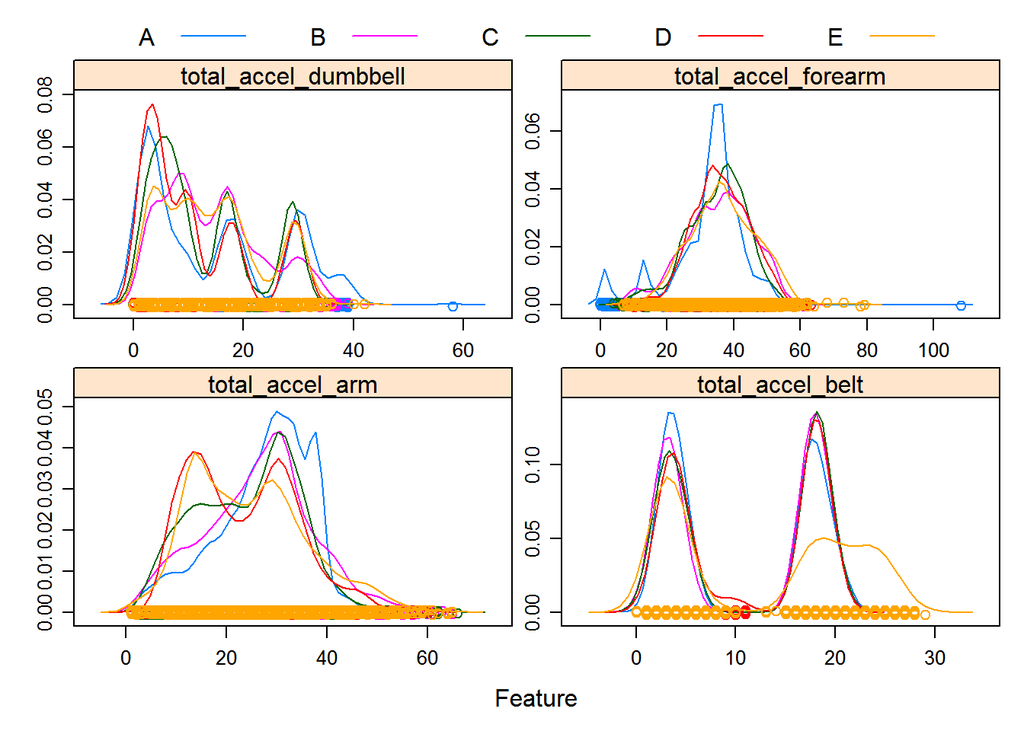

```r
featurePlot(x=training[,c("total_accel_belt","total_accel_arm","total_accel_dumbbell","total_accel_forearm")],y=training$classe,plot="density",
            scales=list(x=list(relation="free"),
                        y=list(relation="free")),auto.key=list(columns=5))
```

#Prediction Model Break the training set into training and validation

```r
inTrain <- createDataPartition(y=training$classe, p=0.7, list=FALSE)
training <- training[inTrain,] # training set
validation <- training[-inTrain,] #validation set
```

Create argument for trainControl function that specifies 10-fold cross validation repeated 10 times

```r
tr_Control <- trainControl(## 10-fold CV
    method = "repeatedcv",
    number = 10,
    ## repeated ten times
    repeats = 10)
```

Create a classification tree model using tr_control argument

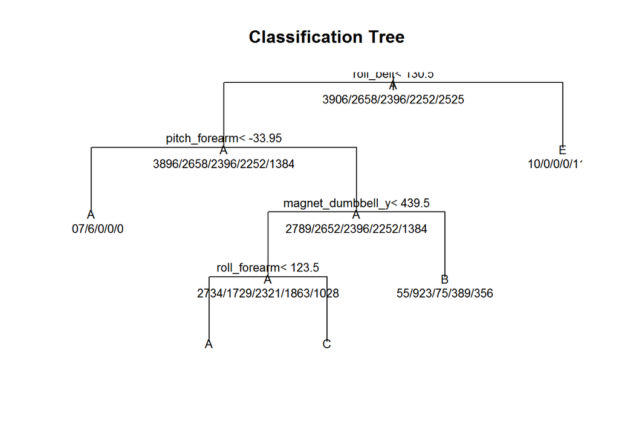

```r
modFit<-train(classe~.,method="rpart",data=training, trControl=tr_Control)
plot(modFit$finalModel,uniform=TRUE,main="Classification Tree")
text(modFit$finalModel,use.n=TRUE,all=TRUE,cex=.8)
```

```r
modFit
```

```
## CART
##
## 13737 samples
##    52 predictor
##     5 classes: 'A', 'B', 'C', 'D', 'E'
##
## No pre-processing
## Resampling: Cross-Validated (10 fold, repeated 10 times)
## Summary of sample sizes: 12363, 12362, 12363, 12362, 12365, 12364, ...
## Resampling results across tuning parameters:
##
##   cp          Accuracy   Kappa
##   0.03499135  0.5164940  0.37127783
##   0.06072627  0.4262535  0.22588438
##   0.11504425  0.3226953  0.05848621
##
## Accuracy was used to select the optimal model using  the largest value.
## The final value used for the model was cp = 0.03499135.
```

```r
tr_ControlRF <- trainControl(## 10-fold CV
    method = "cv",
    number = 10)
modFitRF<-train(classe~.,method="rf",data=training)
modFitRF
```

```
## Random Forest
##
## 13737 samples
##    52 predictor
##     5 classes: 'A', 'B', 'C', 'D', 'E'
##
## No pre-processing
## Resampling: Bootstrapped (25 reps)
## Summary of sample sizes: 13737, 13737, 13737, 13737, 13737, 13737, ...
## Resampling results across tuning parameters:
##
##   mtry  Accuracy   Kappa
##    2    0.9893560  0.9865279
##   27    0.9886022  0.9855741
##   52    0.9808585  0.9757746
##
## Accuracy was used to select the optimal model using  the largest value.
## The final value used for the model was mtry = 2.
```

Test the model on validation set:

```r
pred<-predict(modFitRF,validation)
```

Plot the prediction versus actual

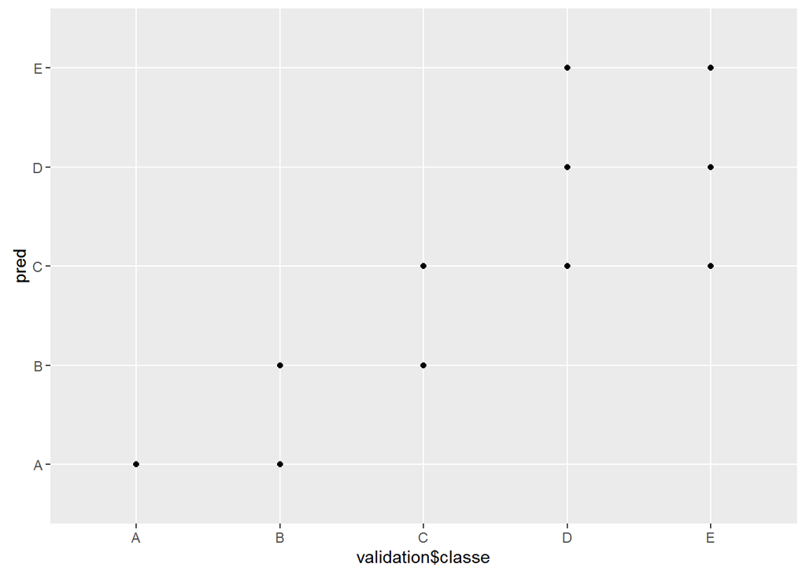

```r
qplot(validation$classe,pred,data=validation)
```

```r
modFitRF$finalModel
```

```
##
## Call:
##  randomForest(x = x, y = y, mtry = param$mtry)
##                Type of random forest: classification
##                      Number of trees: 500
## No. of variables tried at each split: 2
##
##         OOB estimate of  error rate: 0.7%
## Confusion matrix:
##      A    B    C    D    E  class.error
## A 3903    3    0    0    0 0.0007680492
## B   15 2635    8    0    0 0.0086531226
## C    0   21 2373    2    0 0.0095993322
## D    0    0   40 2211    1 0.0182060391
## E    0    0    1    5 2519 0.0023762376
```

We can see the accuracy rate is very good. We expect the out of sample error rate to be (1 - Accuracy).

We can also check confusion matrix, which shows high accuracy

```r
confusionMatrix(pred,validation$classe)
```

```
## Confusion Matrix and Statistics
##
##           Reference
## Prediction    A    B    C    D    E
##          A 1171    2    0    0    0
##          B    0  790    1    0    0
##          C    0    0  729    5    1
##          D    0    0    0  679    1
##          E    0    0    0    1  713
##
## Overall Statistics
##
##                Accuracy : 0.9973
##                  95% CI : (0.9952, 0.9987)
##     No Information Rate : 0.2861
##     P-Value [Acc > NIR] : < 2.2e-16
##
##                   Kappa : 0.9966
##  Mcnemar's Test P-Value : NA
##
## Statistics by Class:
##
##                      Class: A Class: B Class: C Class: D Class: E
## Sensitivity            1.0000   0.9975   0.9986   0.9912   0.9972
## Specificity            0.9993   0.9997   0.9982   0.9997   0.9997
## Pos Pred Value         0.9983   0.9987   0.9918   0.9985   0.9986
## Neg Pred Value         1.0000   0.9994   0.9997   0.9982   0.9994
## Prevalence             0.2861   0.1935   0.1784   0.1674   0.1747
## Detection Rate         0.2861   0.1930   0.1781   0.1659   0.1742
## Detection Prevalence   0.2866   0.1933   0.1796   0.1661   0.1744
## Balanced Accuracy      0.9997   0.9986   0.9984   0.9955   0.9985
```

```r
1-confusionMatrix(pred,validation$class)$overall[[1]]
```

```
## [1] 0.002687515
```